# Basics

```r
library(AER)
library(tidyverse)
```

## Section 1

Summary - Returns some basic summary statistics such as min, max, mean, median. Minimum input is an object. Str - Returns the structure of the specified object. Minimum input is an Object. Names - Returns the names of a vector if available and return NULL if there are no assigned names. Minimum input is an object variable. Glimpse - Similar to str but also returns the first x amount values of the object. Minimum input is an object. LM - Runs and return the results of a linear model regression. Minimum input is the formula and a data frame.

## Section 2

```r
x<- 3+8
y<- 4/5
z<- 2+x^2
variables<-c(x,y,z)
big<- variables>1
big
```

```
## [1]  TRUE FALSE  TRUE
```

## Section 3

```r
a <- c(1:10)
a + 3
```

```
##  [1]  4  5  6  7  8  9 10 11 12 13
```

```r
a ^ 3
```

```
##  [1]    1    8   27   64  125  216  343  512  729 1000
```

```r
b <- c(1:10)
a + b
```

```
##  [1]  2  4  6  8 10 12 14 16 18 20
```

```r
a ^ b
```

```
##  [1]           1           4          27         256        3125       46656
##  [7]      823543    16777216   387420489 10000000000
```

```r
c <- c(a,b)
```

## Section 4

```r
x <- rnorm(100, mean = 10)
e <- rnorm(100)
y <- 3+ 2*x + e
lab_data_df <- data.frame(x,y)
lm(y~x,lab_data_df)
```

[output not shown]

The $\beta_0$ is slighty lower than the expected value of 3 but still within a reasonable standard deviation. The $\beta_1$ is right on the expected value of 2.

```r
xsdbig <- rnorm(100, mean = 10, sd = 20)
esdbig <- rnorm(100, sd = 20)
ysdbig <- 3+ 2*xsdbig + esdbig
lab_data_df_sdbig <- data.frame(xsdbig,ysdbig)
lm(ysdbig ~ xsdbig,lab_data_df_sdbig)

xsdsm <- rnorm(100, mean = 10, sd = .1)
esdsm <- rnorm(100, sd = .1)
ysdsm <- 3+ 2*xsdsm + esdsm
lab_data_df_sdsm <- data.frame(xsdsm,ysdsm)
lm(ysdsm~xsdsm,lab_data_df_sdsm)
```

[output not shown]

Changing the standard deviation affects our $\beta_0$ and our error term. This causes our predicted value to be less accurate when the standard deviation is increased and more accurate when the standard deviation is decreased.

## Section 5

```r
library(haven)
nlsy97_s20 <- read_dta("C:/Users/Corey/Documents/GitHub/data/nlsy97_s20.dta")
View(nlsy97_s20)
```

```r
library(readxl)
X2019nflsalaries <- read_excel("C:/Users/Corey/Documents/GitHub/data/2019nflsalaries.xlsx")
View(X2019nflsalaries)
```

```r
library(tidyverse)
names(nlsy97_s20)
```

```
##  [1] "pubid_1997"                   "grades_8th"
##  [3] "grades_hs"                    "health_1997"
##  [5] "weight_desc_1997"             "both_parents_1997"
##  [7] "sex_1997"                     "bdate_m_1997"
##  [9] "bdate_y_1997"                 "parent_health_1997"
## [11] "parent_feet_1997"             "parent_inches_1997"
## [13] "parent_weight_1997"           "hardtimes_1997"
## [15] "childcare_1997"               "bio_mom_age_youth_1997"
## [17] "census_region_1997"           "citizenship_1997"
## [19] "income_gross_yr_1997"         "hh_net_worth_p_1997"
## [21] "urban_rural_1997"             "hgc_bio_dad_1997"
## [23] "hgc_bio_mom_1997"             "hgc_res_dad_1997"
## [25] "hgc_res_mom_1997"             "race_ethnicity_1997"
## [27] "trans_special_ed_hstr"        "trans_biling_ed_hstr"
## [29] "trans_gifted_crs_hstr"        "trans_class_rank_hstr"
```

[output cut: 17 more lines]

```r
summary(nlsy97_s20$female)
```

```
##    Min. 1st Qu.  Median    Mean 3rd Qu.    Max.
##  0.0000  0.0000  0.0000  0.4881  1.0000  1.0000
```

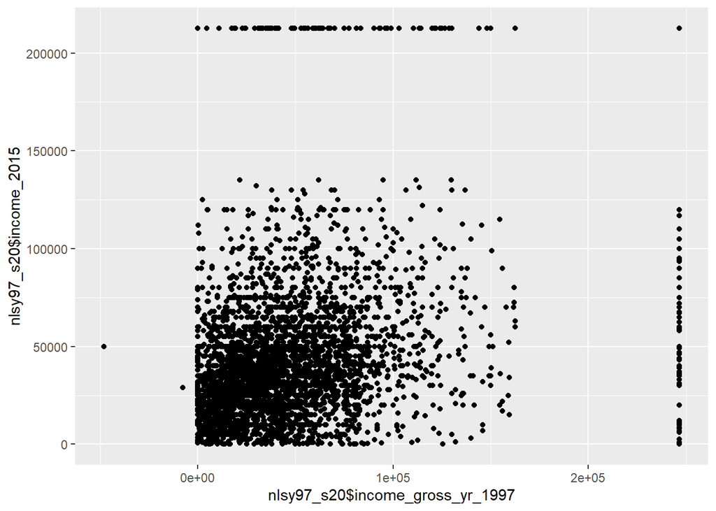

```r
age <- 2015 - nlsy97_s20$bdate_y_1997
age2 <- age^2
ggplot(nlsy97_s20, aes(x = nlsy97_s20$income_gross_yr_1997, y = nlsy97_s20$income_2015)) + geom_point()
```

```r
mean(X2019nflsalaries$Salary)
```

```
## [1] 1860770
```

```r
summary(as.factor(X2019nflsalaries$Pos))
```

```
##     C    CB    DB    DE    DL    DT  EDGE    FB    FS     G    HB   ILB     K
##    52   188    59   122    41   132    14    12    44    35     1    48    33
##    LB LB-DE    LG    LS    LT    NT    OG    OL   OLB    OT     P    QB QB/TE
##   114     1     2    22     1     2    47    24    82    92    36    71     1
##    RB RB-WR     S    SS     T    TE    WR  NA's
##   138     1    57    31    51   123   230     7
```

#The Wide Receiver position has the most salaried players

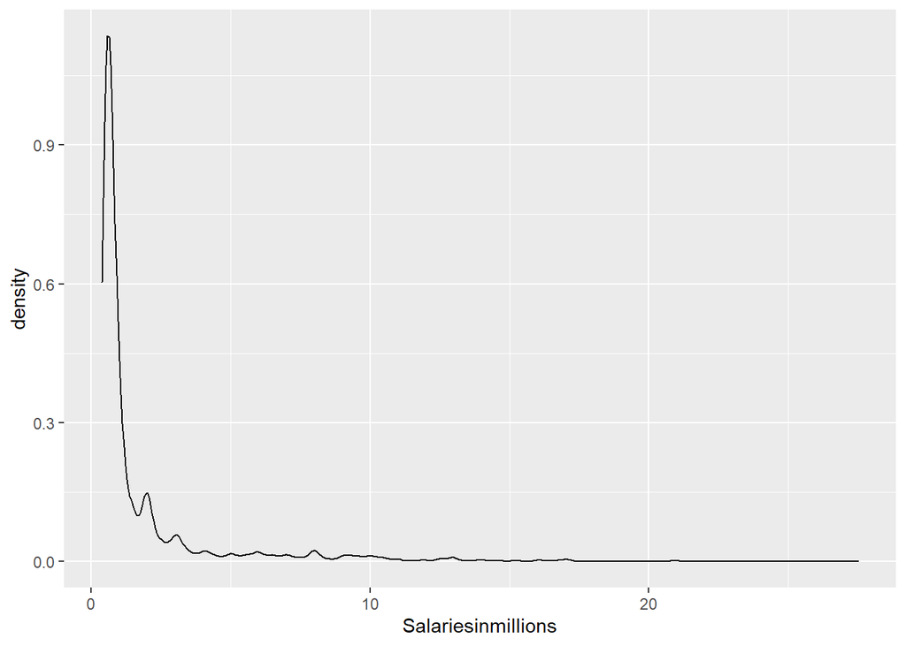

```r
Salariesinmillions<- X2019nflsalaries$Salary/1000000
ggplot(X2019nflsalaries, aes(Salariesinmillions)) + geom_density()
```

```r
teamsalaries <- aggregate(X2019nflsalaries$Salary ~ X2019nflsalaries$Tm, X2019nflsalaries, sum)
teamsalaries
```

```
##    X2019nflsalaries$Tm X2019nflsalaries$Salary
## 1                  2TM               138228597
## 2                  3TM                 6290000
## 3                  ARI               104589128
## 4                  ATL               123845103
## 5                  BAL                94167403
## 6                  BUF                86054781
## 7                  CAR               107847793
## 8                  CHI               105704744
## 9                  CIN                95846247
## 10                 CLE               144200161
## 11                 DAL               115646873
## 12                 DEN               111373819
## 13                 DET               110871457
## 14                 GNB                77404934
```

[output cut: 20 more lines]